# Test parameters for clustering of amphioxus data

Arun Chavan

Started: 2020-12-11  
Last edited: 2021-03-11 20:49:37

# 1 Background

Here we

1. Read QC filtered data
2. Perform normalization (CPT and sctransform) and clustering (Louvain and Leiden)
3. Assess clustering based on number of marker genes and other metrics, and re-assess QC filtration criteria

# 2 Setup

```r
# packages
library(tidyverse)
library(here)
library(glue)

library(ggthemes) # plotting
library(patchwork)
library(cowplot)
library(ggrepel)

library(Seurat) # single cell
library(sctransform)
library(uwot)
```

```r
# here setup
basedir <- here("species/bflo/10x/run_01/refseq__GCF_000003815.2_Bfl_VNyyK")
genomedir <- here("species/bflo/genome/refseq__GCF_000003815.2_Bfl_VNyyK")
```

```r
# ggplot setup
source(here(basedir, "code/utilities_ggplot.R"))
```

```
Updated default font for geoms `text` and `text_repel` to: Source Sans Pro
```

```r
# knitr setup
knitr::opts_chunk$set(dpi = 300)
```

```r
# custom functions
source(here(basedir, "code/utilities_clustering.R"))
```

```
Loaded helper function `merge_clusters()`, which internally runs:
    1. merge_small_clusters()
    2. merge_similar_clusters()
    3. rename_clusters_by_size()
```

# 3 Data

```r
bflo <- readRDS(here(basedir, "data/04_qc/bflo_seurat_qc-filtered.rds"))
```

## 3.1 Read saved objects if starting over

The clustering steps, merging of cluster, and finding markers takes a while. Running all combinations below can take about 5 hours. I have saved to disk the resulting seurat objects and csv files with markers. **If starting over, read these files instead of rerunning all analyses, and skip to the `UMAPs` section below**.

```r
# bf_all <- read_rds(here(basedir, "results/05a_clustering_test-parameters/files/bf_allgenes_seurat-object.rds"))
# bf_good <- read_rds(here(basedir, "results/05a_clustering_test-parameters/files/bf_goodgenes_seurat-object.rds"))
# markers <- read_rds(here(basedir, "results/05a_clustering_test-parameters/files/marker-genes_list-object.rds"))
```

# 4 Gene info

```r
gene.info <- read_tsv(here(genomedir, "gene-info/gene-info_from-gtf.tsv"))

# extract gene lists (replace _ with - for compatibility with how Seurat stores gene names)
genes.rrna <- gene.info %>% filter(gbkey == "rRNA")                       %>% .$gene_id %>% unique() %>% gsub(pattern = "_", replacement = "-")
genes.mt   <- gene.info %>% filter(seqname == "NC_000834.1")              %>% .$gene_id %>% unique() %>% gsub(pattern = "_", replacement = "-")
genes.good <- gene.info %>% filter(!gene_id %in% c(genes.rrna, genes.mt)) %>% .$gene_id %>% unique() %>% gsub(pattern = "_", replacement = "-")
```

Note: two genes are both mitochondrial and rRNA genes, thus percent reads will not add to 100%

# 5 Analyses with different combinations of gene sets, normalization methods, clustering algorithms

## 5.1 All genes

### 5.1.1 CPT normalization

Standard normalization in Seurat: CPT (CPT = Counts per 10k) followed by log transformation.

```r
bf_all <- NormalizeData(bflo, verbose = FALSE) %>%
  FindVariableFeatures(selection.method = "vst", nfeatures = 2000, verbose = FALSE) %>%
  ScaleData(verbose = FALSE) %>%
  RunPCA(npcs = 200, verbose = FALSE) %>%
  FindNeighbors(dims = 1:200, k.param = 20, nn.method = "annoy", annoy.metric = "cosine") %>%
  RunUMAP(dims = 1:200, min.dist = 0.1, umap.method = "umap-learn", metric = "cosine",
          reduction.name = "umap.cpt", reduction.key = "umapCPT_", verbose = FALSE)
```

#### 5.1.1.1 Louvain clustering

```r
DefaultAssay(bf_all) <- "RNA"
bf_all <- FindClusters(bf_all, resolution = 10, algorithm = 1, verbose = FALSE)
bf_all[["all_cpt_louvain_res10"]] <- Idents(bf_all)
```

```r
# merge clusters
bf_all <- merge_clusters(object = bf_all,
                         idents.to.merge = "all_cpt_louvain_res10",
                         idents.merged.name = "all_cpt_louvain_res10_merged")
```

```
Merging small clusters ...
Merged cluster 67 into cluster 48 (correlation: 0.81).
Merged 1 cluster(s) with 10 or fewer cells into their respective nearest neighbours. Now there are 67 clusters.
Renamed 67 clusters by size.
Finished. Elapsed time: 8.73 secs.
Merging similar clusters ...
Merged clusters 13 and 14 (DE genes: 10; correlation: 0.97).
Merged clusters 18 and 42 (DE genes: 6; correlation: 0.96).
Merged clusters 3 and 17 (DE genes: 8; correlation: 0.96).
Merged clusters 19 and 25 (DE genes: 16; correlation: 0.95).
Merged clusters 29 and 45 (DE genes: 4; correlation: 0.95).
Merged clusters 11 and 24 (DE genes: 19; correlation: 0.95).
Merged clusters 6 and 16 (DE genes: 7; correlation: 0.95).
Merged clusters 5 and 23 (DE genes: 5; correlation: 0.93).
Merged clusters 7 and 30 (DE genes: 10; correlation: 0.93).
Merged clusters 1 and 34 (DE genes: 10; correlation: 0.93).
Merged clusters 40 and 64 (DE genes: 15; correlation: 0.91).
Merged clusters 12 and 33 (DE genes: 19; correlation: 0.91).
Merged clusters 35 and 37 (DE genes: 8; correlation: 0.88).
Merged clusters 32 and 38 (DE genes: 19; correlation: 0.86).
Merged clusters 31 and 46 (DE genes: 16; correlation: 0.85).
Merged clusters 51 and 52 (DE genes: 12; correlation: 0.84).
Merged clusters 22 and 48 (DE genes: 4; correlation: 0.77).
Merged clusters 15 and 63 (DE genes: 5; correlation: 0.76).
Merged clusters 57 and 65 (DE genes: 19; correlation: 0.71).
Merged clusters 56 and 59 (DE genes: 13; correlation: 0.56).
Merged clusters 53 and 67 (DE genes: 16; correlation: 0.51).
Merged clusters 58 and 60 (DE genes: 19; correlation: 0.35).
Merged clusters 18.42 and 29.45 (DE genes: 7; correlation: 0.97).
Merged clusters 11.24 and 4 (DE genes: 19; correlation: 0.96).
Merged clusters 35.37 and 6.16 (DE genes: 8; correlation: 0.95).
Merged clusters 13.14 and 51.52 (DE genes: 3; correlation: 0.94).
Merged clusters 32.38 and 5.23 (DE genes: 15; correlation: 0.92).
Merged clusters 1.34 and 54 (DE genes: 13; correlation: 0.91).
Merged clusters 18.42.29.45 and 35.37.6.16 (DE genes: 0; correlation: 0.96).
Merged clusters 18.42.29.45.35.37.6.16 and 7.30 (DE genes: 17; correlation: 0.95).
Finished merging nearest-neighbour clusters with fewer than 20 DE genes with a fold difference of 2.
Renamed 37 clusters by size.
Finished. Elapsed time: 11.33 mins.
```

#### 5.1.1.2 Leiden clustering

```r
DefaultAssay(bf_all) <- "RNA"
bf_all <- FindClusters(bf_all, resolution = 10, algorithm = 4, verbose = FALSE)
bf_all[["all_cpt_leiden_res10"]] <- Idents(bf_all)
```

```r
# merge clusters
bf_all <- merge_clusters(object = bf_all,
                         idents.to.merge = "all_cpt_leiden_res10",
                         idents.merged.name = "all_cpt_leiden_res10_merged")
```

```
Merging small clusters ...
Merged cluster 71 into cluster 16 (correlation: 0.65).
Merged cluster 70 into cluster 5 (correlation: 0.73).
Merged 2 cluster(s) with 10 or fewer cells into their respective nearest neighbours. Now there are 69 clusters.
Renamed 69 clusters by size.
Finished. Elapsed time: 17.5 secs.
Merging similar clusters ...
Merged clusters 11 and 14 (DE genes: 10; correlation: 0.97).
Merged clusters 17 and 40 (DE genes: 4; correlation: 0.97).
Merged clusters 3 and 15 (DE genes: 6; correlation: 0.95).
Merged clusters 18 and 25 (DE genes: 14; correlation: 0.95).
Merged clusters 10 and 22 (DE genes: 19; correlation: 0.95).
Merged clusters 6 and 28 (DE genes: 8; correlation: 0.94).
Merged clusters 7 and 24 (DE genes: 5; correlation: 0.94).
Merged clusters 5 and 23 (DE genes: 5; correlation: 0.93).
Merged clusters 1 and 34 (DE genes: 10; correlation: 0.93).
Merged clusters 21 and 45 (DE genes: 3; correlation: 0.91).
Merged clusters 16 and 36 (DE genes: 14; correlation: 0.9).
Merged clusters 46 and 58 (DE genes: 3; correlation: 0.87).
Merged clusters 32 and 37 (DE genes: 19; correlation: 0.86).
Merged clusters 30 and 47 (DE genes: 15; correlation: 0.85).
Merged clusters 49 and 53 (DE genes: 12; correlation: 0.85).
Merged clusters 33 and 59 (DE genes: 15; correlation: 0.78).
Merged clusters 13 and 64 (DE genes: 6; correlation: 0.78).
Merged clusters 20 and 57 (DE genes: 9; correlation: 0.75).
Merged clusters 9 and 67 (DE genes: 19; correlation: 0.62).
Merged clusters 65 and 66 (DE genes: 16; correlation: 0.51).
Merged clusters 60 and 61 (DE genes: 14; correlation: 0.46).
Merged clusters 21.45 and 7.24 (DE genes: 5; correlation: 0.96).
Merged clusters 46.58 and 6.28 (DE genes: 6; correlation: 0.94).
Merged clusters 11.14 and 49.53 (DE genes: 3; correlation: 0.94).
Merged clusters 32.37 and 5.23 (DE genes: 14; correlation: 0.92).
Merged clusters 16.36 and 17.40 (DE genes: 15; correlation: 0.92).
Merged clusters 1.34 and 56 (DE genes: 13; correlation: 0.91).
Merged clusters 20.57 and 33.59 (DE genes: 18; correlation: 0.8).
Merged clusters 50 and 65.66 (DE genes: 14; correlation: 0.77).
Merged clusters 16.36.17.40 and 21.45.7.24 (DE genes: 8; correlation: 0.96).
Merged clusters 16.36.17.40.21.45.7.24 and 46.58.6.28 (DE genes: 13; correlation: 0.96).
Merged clusters 16.36.17.40.21.45.7.24.46.58.6.28 and 20.57.33.59 (DE genes: 18; correlation: 0.89).
Finished merging nearest-neighbour clusters with fewer than 20 DE genes with a fold difference of 2.
Renamed 37 clusters by size.
Finished. Elapsed time: 11.26 mins.
```

### 5.1.2 SCT normalization

Perform SCT normalization:

```r
bf_all <- SCTransform(bf_all, vars.to.regress = "percent.mt",
                      conserve.memory = T, verbose = FALSE) %>%
  RunPCA(assay = "SCT", npcs = 200,
         reduction.name = "pca.sct", reduction.key = "pcaSCT_", verbose = FALSE) %>%
  FindNeighbors(dims = 1:200, reduction = "pca.sct",
                k.param = 20, nn.method = "annoy",
                annoy.metric = "cosine", verbose = FALSE) %>%
  RunUMAP(reduction = "pca.sct", dims = 1:200, min.dist = 0.1,
          umap.method = "umap-learn", metric = "cosine",
          reduction.name = "umap.sct", reduction.key = "umapSCT_", verbose = FALSE)
```

#### 5.1.2.1 Louvain clustering

```r
DefaultAssay(bf_all) <- "SCT"
bf_all <- FindClusters(bf_all,  resolution = 10, algorithm = 1, graph.name = "SCT_snn", verbose = FALSE)
bf_all[["all_sct_louvain_res10"]] <- Idents(bf_all)
```

```r
# merge clusters
bf_all <- merge_clusters(object = bf_all,
                         idents.to.merge = "all_sct_louvain_res10",
                         idents.merged.name = "all_sct_louvain_res10_merged")
```

```
Merging small clusters ...
Merged cluster 73 into cluster 38 (correlation: 0.93).
Merged cluster 72 into cluster 58 (correlation: 0.89).
Merged 2 cluster(s) with 10 or fewer cells into their respective nearest neighbours. Now there are 72 clusters.
Renamed 72 clusters by size.
Finished. Elapsed time: 12.82 secs.
Merging similar clusters ...
Merged clusters 2 and 12 (DE genes: 2; correlation: 0.98).
Merged clusters 31 and 33 (DE genes: 4; correlation: 0.98).
Merged clusters 13 and 19 (DE genes: 2; correlation: 0.97).
Merged clusters 16 and 23 (DE genes: 12; correlation: 0.97).
Merged clusters 10 and 50 (DE genes: 11; correlation: 0.96).
Merged clusters 18 and 49 (DE genes: 7; correlation: 0.96).
Merged clusters 5 and 42 (DE genes: 15; correlation: 0.96).
Merged clusters 14 and 36 (DE genes: 19; correlation: 0.95).
Merged clusters 22 and 24 (DE genes: 16; correlation: 0.95).
Merged clusters 8 and 51 (DE genes: 9; correlation: 0.94).
Merged clusters 28 and 62 (DE genes: 4; correlation: 0.94).
Merged clusters 44 and 59 (DE genes: 3; correlation: 0.94).
Merged clusters 1 and 41 (DE genes: 14; correlation: 0.93).
Merged clusters 20 and 63 (DE genes: 17; correlation: 0.92).
Merged clusters 3 and 72 (DE genes: 11; correlation: 0.91).
Merged clusters 39 and 52 (DE genes: 19; correlation: 0.86).
Merged clusters 27 and 55 (DE genes: 9; correlation: 0.85).
Merged clusters 48 and 66 (DE genes: 17; correlation: 0.73).
Merged clusters 53 and 71 (DE genes: 18; correlation: 0.65).
Merged clusters 65 and 69 (DE genes: 8; correlation: 0.64).
Merged clusters 2.12 and 44.59 (DE genes: 5; correlation: 0.98).
Merged clusters 13.19 and 31.33 (DE genes: 4; correlation: 0.97).
Merged clusters 18.49 and 8.51 (DE genes: 17; correlation: 0.95).
Merged clusters 14.36 and 27.55 (DE genes: 5; correlation: 0.94).
Merged clusters 48.66 and 65.69 (DE genes: 13; correlation: 0.77).
Merged clusters 13.19.31.33 and 18.49.8.51 (DE genes: 2; correlation: 0.98).
Merged clusters 13.19.31.33.18.49.8.51 and 4 (DE genes: 16; correlation: 0.93).
Finished merging nearest-neighbour clusters with fewer than 20 DE genes with a fold difference of 2.
Renamed 45 clusters by size.
Finished. Elapsed time: 13.62 mins.
```

#### 5.1.2.2 Leiden clustering

```r
DefaultAssay(bf_all) <- "SCT"
bf_all <- FindClusters(bf_all,  resolution = 10, algorithm = 4, graph.name = "SCT_snn", verbose = FALSE)
bf_all[["all_sct_leiden_res10"]] <- Idents(bf_all)
```

```r
# merge clusters
bf_all <- merge_clusters(object = bf_all,
                         idents.to.merge = "all_sct_leiden_res10",
                         idents.merged.name = "all_sct_leiden_res10_merged")
```

```
Merging small clusters ...
All clusters already have more than 10 cells. No clusters were merged.
Finished. Elapsed time: 0.06 secs.
Merging similar clusters ...
Merged clusters 2 and 8 (DE genes: 1; correlation: 0.98).
Merged clusters 29 and 41 (DE genes: 3; correlation: 0.98).
Merged clusters 33 and 38 (DE genes: 6; correlation: 0.98).
Merged clusters 11 and 19 (DE genes: 2; correlation: 0.97).
Merged clusters 14 and 21 (DE genes: 12; correlation: 0.97).
Merged clusters 9 and 53 (DE genes: 11; correlation: 0.96).
Merged clusters 16 and 52 (DE genes: 6; correlation: 0.96).
Merged clusters 7 and 43 (DE genes: 16; correlation: 0.96).
Merged clusters 12 and 32 (DE genes: 19; correlation: 0.95).
Merged clusters 20 and 22 (DE genes: 14; correlation: 0.95).
Merged clusters 46 and 71 (DE genes: 2; correlation: 0.95).
Merged clusters 28 and 51 (DE genes: 13; correlation: 0.94).
Merged clusters 25 and 64 (DE genes: 3; correlation: 0.94).
Merged clusters 1 and 39 (DE genes: 14; correlation: 0.93).
Merged clusters 54 and 77 (DE genes: 3; correlation: 0.93).
Merged clusters 5 and 74 (DE genes: 17; correlation: 0.93).
Merged clusters 17 and 66 (DE genes: 17; correlation: 0.92).
Merged clusters 37 and 61 (DE genes: 12; correlation: 0.91).
Merged clusters 62 and 72 (DE genes: 2; correlation: 0.9).
Merged clusters 45 and 47 (DE genes: 15; correlation: 0.89).
Merged clusters 26 and 57 (DE genes: 9; correlation: 0.85).
Merged clusters 50 and 70 (DE genes: 17; correlation: 0.73).
Merged clusters 56 and 76 (DE genes: 18; correlation: 0.65).
Merged clusters 68 and 73 (DE genes: 8; correlation: 0.64).
Merged clusters 11.19 and 29.41 (DE genes: 3; correlation: 0.97).
Merged clusters 2.8 and 46.71 (DE genes: 4; correlation: 0.97).
Merged clusters 16.52 and 33.38 (DE genes: 19; correlation: 0.96).
Merged clusters 14.21 and 54.77 (DE genes: 9; correlation: 0.94).
Merged clusters 12.32 and 26.57 (DE genes: 5; correlation: 0.94).
Merged clusters 5.74 and 62.72 (DE genes: 18; correlation: 0.91).
Merged clusters 50.70 and 68.73 (DE genes: 13; correlation: 0.77).
Merged clusters 11.19.29.41 and 16.52.33.38 (DE genes: 2; correlation: 0.98).
Merged clusters 14.21.54.77 and 6 (DE genes: 17; correlation: 0.92).
Merged clusters 11.19.29.41.16.52.33.38 and 14.21.54.77.6 (DE genes: 10; correlation: 0.97).
Finished merging nearest-neighbour clusters with fewer than 20 DE genes with a fold difference of 2.
Renamed 43 clusters by size.
Finished. Elapsed time: 11.73 mins.
```

## 5.2 Good genes

Count matrix without the mitochondrial and rRNA genes

```r
bf_good <- subset(bflo, features = genes.good)
```

### 5.2.1 CPT normalization

```r
bf_good <- NormalizeData(bf_good, verbose = FALSE) %>%
  FindVariableFeatures(selection.method = "vst", nfeatures = 2000, verbose = FALSE) %>%
  ScaleData(verbose = FALSE) %>%
  RunPCA(npcs = 200, verbose = FALSE) %>%
  FindNeighbors(dims = 1:200, k.param = 20, nn.method = "annoy", annoy.metric = "cosine") %>%
  RunUMAP(dims = 1:200, min.dist = 0.3, umap.method = "umap-learn", metric = "cosine",
          reduction.name = "umap.cpt", reduction.key = "umapCPT_", verbose = FALSE)
```

#### 5.2.1.1 Louvain clustering

```r
DefaultAssay(bf_good) <- "RNA"
bf_good <- FindClusters(bf_good, resolution = 10, algorithm = 1, verbose = FALSE)
bf_good[["good_cpt_louvain_res10"]] <- Idents(bf_good)
```

```r
# merge clusters
bf_good <- merge_clusters(object = bf_good,
                          idents.to.merge = "good_cpt_louvain_res10",
                          idents.merged.name = "good_cpt_louvain_res10_merged")
```

```
Merging small clusters ...
All clusters already have more than 10 cells. No clusters were merged.
Finished. Elapsed time: 0.03 secs.
Merging similar clusters ...
Merged clusters 16 and 34 (DE genes: 3; correlation: 0.98).
Merged clusters 14 and 15 (DE genes: 10; correlation: 0.97).
Merged clusters 2 and 18 (DE genes: 11; correlation: 0.95).
Merged clusters 20 and 26 (DE genes: 12; correlation: 0.95).
Merged clusters 9 and 22 (DE genes: 17; correlation: 0.94).
Merged clusters 6 and 17 (DE genes: 3; correlation: 0.94).
Merged clusters 5 and 19 (DE genes: 17; correlation: 0.93).
Merged clusters 0 and 29 (DE genes: 11; correlation: 0.93).
Merged clusters 4 and 23 (DE genes: 5; correlation: 0.93).
Merged clusters 10 and 41 (DE genes: 3; correlation: 0.93).
Merged clusters 32 and 44 (DE genes: 8; correlation: 0.86).
Merged clusters 48 and 53 (DE genes: 14; correlation: 0.84).
Merged clusters 30 and 61 (DE genes: 2; correlation: 0.84).
Merged clusters 45 and 49 (DE genes: 13; correlation: 0.81).
Merged clusters 24 and 38 (DE genes: 10; correlation: 0.78).
Merged clusters 55 and 56 (DE genes: 9; correlation: 0.67).
Merged clusters 51 and 66 (DE genes: 7; correlation: 0.62).
Merged clusters 60 and 67 (DE genes: 7; correlation: 0.53).
Merged clusters 63 and 64 (DE genes: 17; correlation: 0.49).
Merged clusters 57 and 65 (DE genes: 8; correlation: 0.37).
Merged clusters 5.19 and 6.17 (DE genes: 6; correlation: 0.95).
Merged clusters 10.41 and 16.34 (DE genes: 2; correlation: 0.95).
Merged clusters 14.15 and 48.53 (DE genes: 3; correlation: 0.95).
Merged clusters 30.61 and 4.23 (DE genes: 2; correlation: 0.94).
Merged clusters 0.29 and 54 (DE genes: 12; correlation: 0.91).
Merged clusters 24.38 and 32.44 (DE genes: 13; correlation: 0.87).
Merged clusters 13 and 51.66 (DE genes: 18; correlation: 0.85).
Merged clusters 45.49 and 55.56 (DE genes: 18; correlation: 0.79).
Merged clusters 47 and 63.64 (DE genes: 15; correlation: 0.76).
Merged clusters 57.65 and 60.67 (DE genes: 12; correlation: 0.51).
Merged clusters 10.41.16.34 and 5.19.6.17 (DE genes: 16; correlation: 0.95).
Merged clusters 13.51.66 and 36 (DE genes: 18; correlation: 0.89).
Merged clusters 10.41.16.34.5.19.6.17 and 24.38.32.44 (DE genes: 7; correlation: 0.94).
Finished merging nearest-neighbour clusters with fewer than 20 DE genes with a fold difference of 2.
Renamed 36 clusters by size.
Finished. Elapsed time: 7.07 mins.
```

#### 5.2.1.2 Leiden clustering

```r
DefaultAssay(bf_good) <- "RNA"
bf_good <- FindClusters(bf_good, resolution = 10, algorithm = 4, verbose = FALSE)
bf_good[["good_cpt_leiden_res10"]] <- Idents(bf_good)
```

```r
# merge clusters
bf_good <- merge_clusters(object = bf_good,
                          idents.to.merge = "good_cpt_leiden_res10",
                          idents.merged.name = "good_cpt_leiden_res10_merged")
```

```
Merging small clusters ...
Merged cluster 72 into cluster 32 (correlation: 0.74).
Merged 1 cluster(s) with 10 or fewer cells into their respective nearest neighbours. Now there are 71 clusters.
Renamed 71 clusters by size.
Finished. Elapsed time: 6.55 secs.
Merging similar clusters ...
Merged clusters 20 and 28 (DE genes: 4; correlation: 0.97).
Merged clusters 12 and 13 (DE genes: 10; correlation: 0.97).
Merged clusters 3 and 16 (DE genes: 10; correlation: 0.96).
Merged clusters 21 and 25 (DE genes: 12; correlation: 0.95).
Merged clusters 4 and 19 (DE genes: 10; correlation: 0.94).
Merged clusters 5 and 30 (DE genes: 12; correlation: 0.94).
Merged clusters 1 and 31 (DE genes: 11; correlation: 0.93).
Merged clusters 15 and 17 (DE genes: 3; correlation: 0.93).
Merged clusters 6 and 23 (DE genes: 5; correlation: 0.93).
Merged clusters 14 and 45 (DE genes: 8; correlation: 0.92).
Merged clusters 18 and 42 (DE genes: 19; correlation: 0.89).
Merged clusters 37 and 52 (DE genes: 19; correlation: 0.88).
Merged clusters 36 and 51 (DE genes: 3; correlation: 0.88).
Merged clusters 32 and 64 (DE genes: 2; correlation: 0.85).
Merged clusters 48 and 55 (DE genes: 13; correlation: 0.85).
Merged clusters 35 and 62 (DE genes: 6; correlation: 0.81).
Merged clusters 46 and 50 (DE genes: 13; correlation: 0.81).
Merged clusters 27 and 57 (DE genes: 13; correlation: 0.77).
Merged clusters 59 and 61 (DE genes: 6; correlation: 0.61).
Merged clusters 54 and 70 (DE genes: 19; correlation: 0.52).
Merged clusters 66 and 69 (DE genes: 17; correlation: 0.49).
Merged clusters 63 and 68 (DE genes: 10; correlation: 0.45).
Merged clusters 44 and 67 (DE genes: 14; correlation: 0.36).
Merged clusters 14.45 and 20.28 (DE genes: 4; correlation: 0.96).
Merged clusters 36.51 and 5.30 (DE genes: 7; correlation: 0.95).
Merged clusters 12.13 and 48.55 (DE genes: 3; correlation: 0.95).
Merged clusters 32.64 and 6.23 (DE genes: 2; correlation: 0.94).
Merged clusters 15.17 and 35.62 (DE genes: 13; correlation: 0.91).
Merged clusters 1.31 and 56 (DE genes: 12; correlation: 0.91).
Merged clusters 49 and 66.69 (DE genes: 14; correlation: 0.77).
Merged clusters 46.50 and 59.61 (DE genes: 18; correlation: 0.73).
Merged clusters 14.45.20.28 and 15.17.35.62 (DE genes: 0; correlation: 0.96).
Merged clusters 14.45.20.28.15.17.35.62 and 36.51.5.30 (DE genes: 15; correlation: 0.96).
Finished merging nearest-neighbour clusters with fewer than 20 DE genes with a fold difference of 2.
Renamed 38 clusters by size.
Finished. Elapsed time: 7.67 mins.
```

### 5.2.2 SCT normalization

Perform SCT normalization:

```r
bf_good <- SCTransform(bf_good,
                      conserve.memory = T, verbose = FALSE) %>%
  RunPCA(assay = "SCT", npcs = 200,
         reduction.name = "pca.sct", reduction.key = "pcaSCT_", verbose = FALSE) %>%
  FindNeighbors(dims = 1:200, reduction = "pca.sct",
                k.param = 20, nn.method = "annoy",
                annoy.metric = "cosine", verbose = FALSE) %>%
  RunUMAP(reduction = "pca.sct", dims = 1:200, min.dist = 0.1,
          umap.method = "umap-learn", metric = "cosine",
          reduction.name = "umap.sct", reduction.key = "umapSCT_", verbose = FALSE)
```

#### 5.2.2.1 Louvain clustering

```r
DefaultAssay(bf_good) <- "SCT"
bf_good <- FindClusters(bf_good,  resolution = 10, algorithm = 1, graph.name = "SCT_snn", verbose = FALSE)
bf_good[["good_sct_louvain_res10"]] <- Idents(bf_good)
```

```r
# merge clusters
bf_good <- merge_clusters(object = bf_good,
                          idents.to.merge = "good_sct_louvain_res10",
                          idents.merged.name = "good_sct_louvain_res10_merged")
```

```
Merging small clusters ...
Merged cluster 74 into cluster 54 (correlation: 0.28).
Merged cluster 73 into cluster 42 (correlation: 0.93).
Merged 2 cluster(s) with 10 or fewer cells into their respective nearest neighbours. Now there are 73 clusters.
Renamed 73 clusters by size.
Finished. Elapsed time: 12.54 secs.
Merging similar clusters ...
Merged clusters 2 and 13 (DE genes: 1; correlation: 0.98).
Merged clusters 6 and 32 (DE genes: 1; correlation: 0.98).
Merged clusters 30 and 44 (DE genes: 2; correlation: 0.98).
Merged clusters 11 and 16 (DE genes: 3; correlation: 0.97).
Merged clusters 8 and 50 (DE genes: 11; correlation: 0.97).
Merged clusters 12 and 17 (DE genes: 10; correlation: 0.97).
Merged clusters 5 and 41 (DE genes: 15; correlation: 0.96).
Merged clusters 18 and 33 (DE genes: 17; correlation: 0.95).
Merged clusters 48 and 67 (DE genes: 2; correlation: 0.95).
Merged clusters 22 and 39 (DE genes: 11; correlation: 0.95).
Merged clusters 20 and 26 (DE genes: 16; correlation: 0.94).
Merged clusters 27 and 58 (DE genes: 3; correlation: 0.94).
Merged clusters 1 and 38 (DE genes: 14; correlation: 0.93).
Merged clusters 3 and 59 (DE genes: 14; correlation: 0.92).
Merged clusters 35 and 56 (DE genes: 12; correlation: 0.9).
Merged clusters 52 and 71 (DE genes: 2; correlation: 0.9).
Merged clusters 21 and 55 (DE genes: 10; correlation: 0.88).
Merged clusters 51 and 65 (DE genes: 12; correlation: 0.83).
Merged clusters 64 and 73 (DE genes: 10; correlation: 0.71).
Merged clusters 60 and 62 (DE genes: 18; correlation: 0.64).
Merged clusters 43 and 69 (DE genes: 16; correlation: 0.61).
Merged clusters 22.39 and 30.44 (DE genes: 1; correlation: 0.99).
Merged clusters 11.16 and 6.32 (DE genes: 3; correlation: 0.97).
Merged clusters 2.13 and 48.67 (DE genes: 4; correlation: 0.97).
Merged clusters 18.33 and 21.55 (DE genes: 6; correlation: 0.94).
Merged clusters 12.17 and 52.71 (DE genes: 13; correlation: 0.94).
Merged clusters 60.62 and 63 (DE genes: 18; correlation: 0.65).
Merged clusters 11.16.6.32 and 22.39.30.44 (DE genes: 11; correlation: 0.98).
Merged clusters 11.16.6.32.22.39.30.44 and 12.17.52.71 (DE genes: 19; correlation: 0.97).
Finished merging nearest-neighbour clusters with fewer than 20 DE genes with a fold difference of 2.
Renamed 44 clusters by size.
Finished. Elapsed time: 11.77 mins.
```

#### 5.2.2.2 Leiden clustering

```r
DefaultAssay(bf_good) <- "SCT"
bf_good <- FindClusters(bf_good,  resolution = 10, algorithm = 4, graph.name = "SCT_snn", verbose = FALSE)
bf_good[["good_sct_leiden_res10"]] <- Idents(bf_good)
```

```r
# merge clusters
bf_good <- merge_clusters(object = bf_good,
                         idents.to.merge = "good_sct_leiden_res10",
                         idents.merged.name = "good_sct_leiden_res10_merged")
```

```
Merging small clusters ...
Merged cluster 79 into cluster 55 (correlation: 0.28).
Merged cluster 78 into cluster 4 (correlation: 0.9).
Merged cluster 77 into cluster 41 (correlation: 0.93).
Merged 3 cluster(s) with 10 or fewer cells into their respective nearest neighbours. Now there are 76 clusters.
Renamed 76 clusters by size.
Finished. Elapsed time: 20.98 secs.
Merging similar clusters ...
Merged clusters 40 and 42 (DE genes: 1; correlation: 0.99).
Merged clusters 9 and 23 (DE genes: 2; correlation: 0.98).
Merged clusters 7 and 30 (DE genes: 1; correlation: 0.98).
Merged clusters 11 and 16 (DE genes: 3; correlation: 0.97).
Merged clusters 20 and 61 (DE genes: 1; correlation: 0.97).
Merged clusters 5 and 50 (DE genes: 11; correlation: 0.97).
Merged clusters 10 and 14 (DE genes: 11; correlation: 0.97).
Merged clusters 4 and 45 (DE genes: 15; correlation: 0.96).
Merged clusters 17 and 67 (DE genes: 2; correlation: 0.96).
Merged clusters 15 and 33 (DE genes: 17; correlation: 0.95).
Merged clusters 38 and 51 (DE genes: 10; correlation: 0.94).
Merged clusters 19 and 26 (DE genes: 16; correlation: 0.94).
Merged clusters 1 and 39 (DE genes: 13; correlation: 0.94).
Merged clusters 28 and 59 (DE genes: 3; correlation: 0.94).
Merged clusters 32 and 52 (DE genes: 14; correlation: 0.93).
Merged clusters 2 and 60 (DE genes: 14; correlation: 0.92).
Merged clusters 18 and 66 (DE genes: 18; correlation: 0.92).
Merged clusters 35 and 57 (DE genes: 12; correlation: 0.9).
Merged clusters 21 and 55 (DE genes: 10; correlation: 0.88).
Merged clusters 49 and 73 (DE genes: 7; correlation: 0.85).
Merged clusters 44 and 70 (DE genes: 19; correlation: 0.75).
Merged clusters 69 and 76 (DE genes: 10; correlation: 0.71).
Merged clusters 62 and 71 (DE genes: 15; correlation: 0.65).
Merged clusters 65 and 68 (DE genes: 17; correlation: 0.64).
Merged clusters 17.67 and 9.23 (DE genes: 3; correlation: 0.98).
Merged clusters 11.16 and 40.42 (DE genes: 2; correlation: 0.97).
Merged clusters 20.61 and 7.30 (DE genes: 13; correlation: 0.96).
Merged clusters 15.33 and 21.55 (DE genes: 6; correlation: 0.94).
Merged clusters 49.73 and 65.68 (DE genes: 19; correlation: 0.82).
Merged clusters 11.16.40.42 and 20.61.7.30 (DE genes: 2; correlation: 0.98).
Merged clusters 11.16.40.42.20.61.7.30 and 38.51 (DE genes: 8; correlation: 0.97).
Finished merging nearest-neighbour clusters with fewer than 20 DE genes with a fold difference of 2.
Renamed 45 clusters by size.
Finished. Elapsed time: 12.22 mins.
```

# 6 UMAPs

```r
plot_umap <- function(genes, norm.method, clust.method) {
  object <- get(glue("bf_{genes}"))
  object <- SetIdent(object, value = glue("{genes}_{norm.method}_{clust.method}_res10_merged"))
  p <- DimPlot(object, reduction = glue("umap.{norm.method}"), label = TRUE, repel = TRUE) +
    labs(subtitle = glue("{genes} genes, {norm.method}, {clust.method}")) +
    theme_half_open_nogrid() +
    theme(aspect.ratio = 1)

  ggsave(here(basedir, glue("results/05a_clustering_test-parameters/plots/umap_{genes}genes_{norm.method}_{clust.method}.pdf")), plot = p, device = cairo_pdf, width = 5.5, height = 4.5, units = "in")

  print(p)
}
```

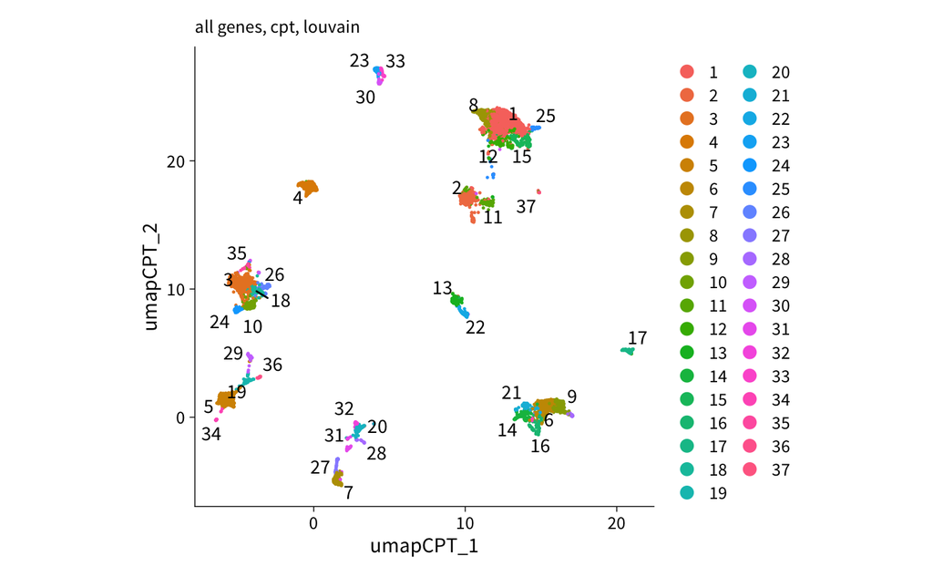

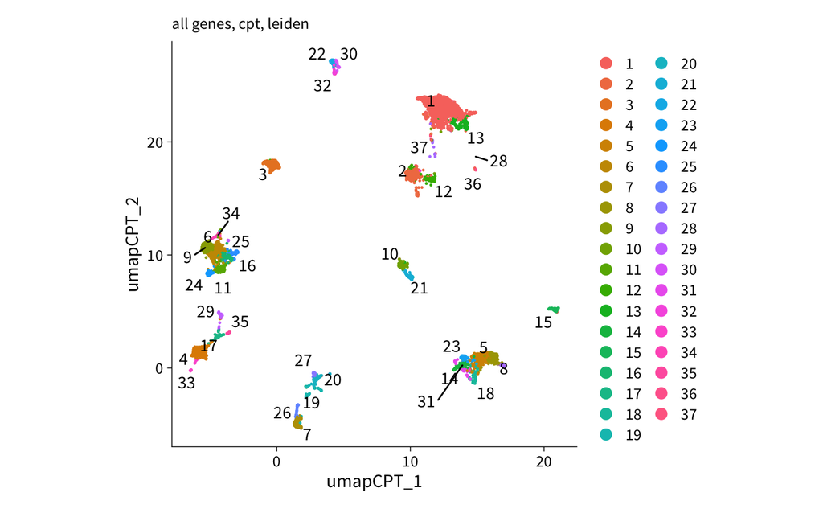

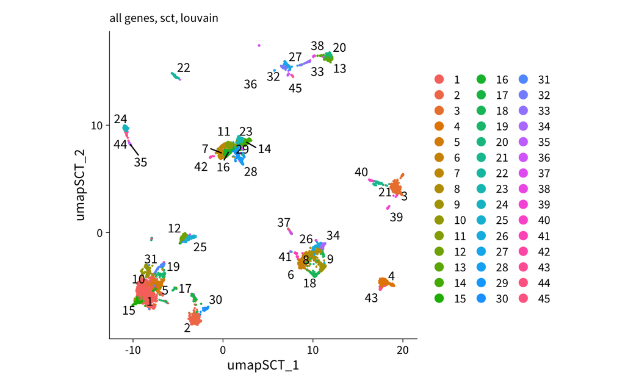

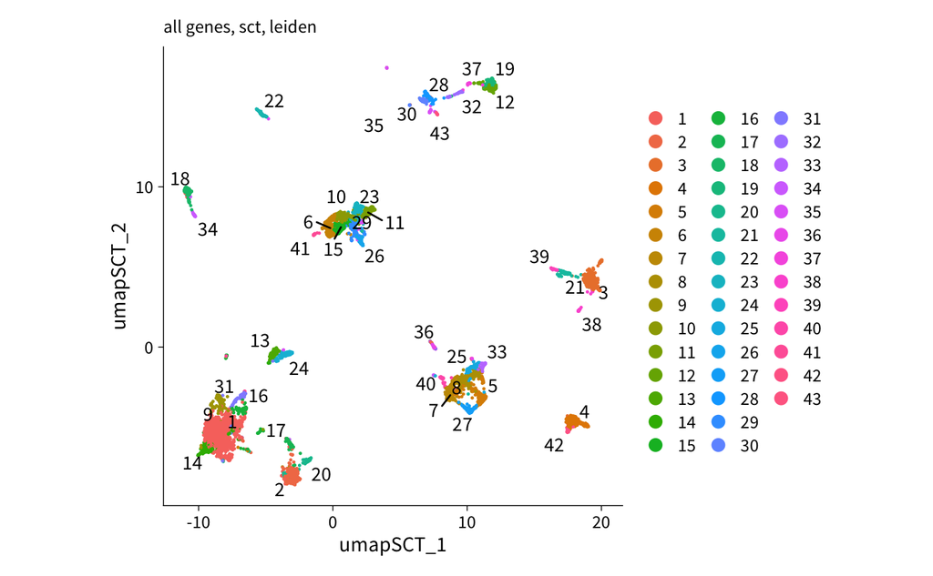

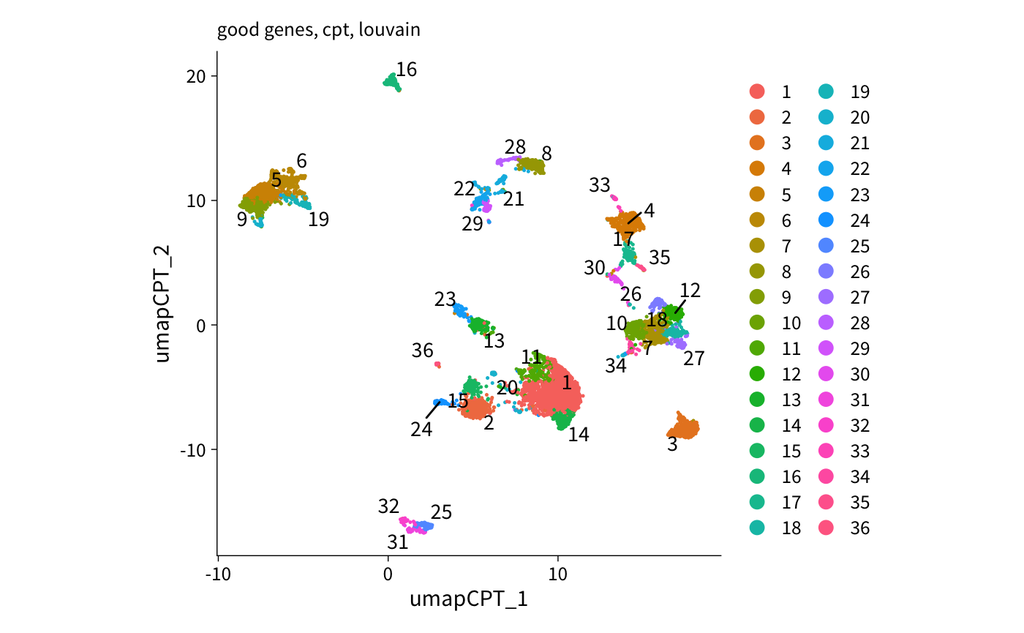

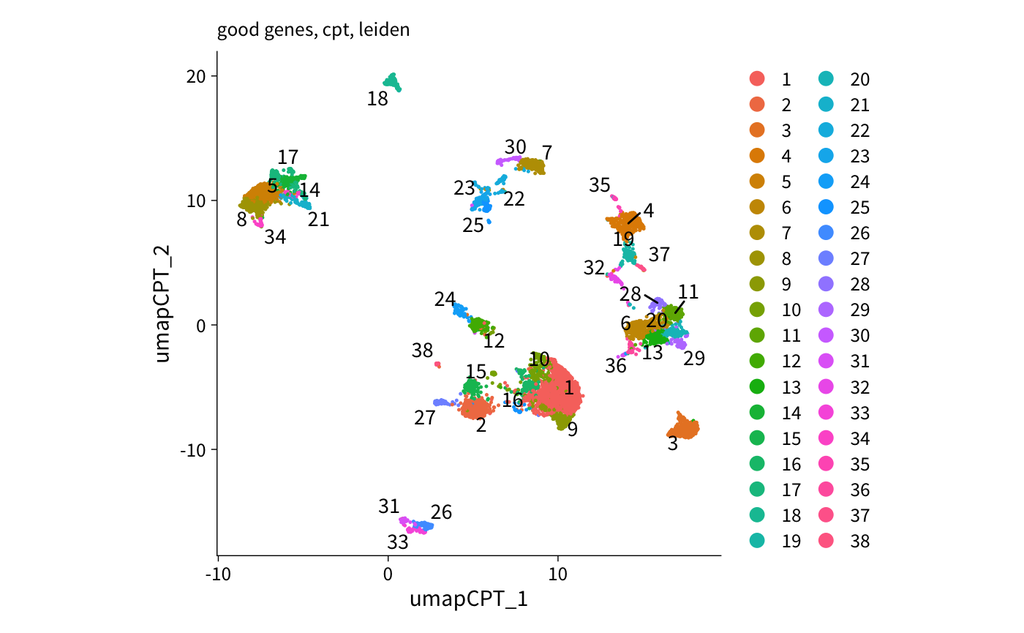

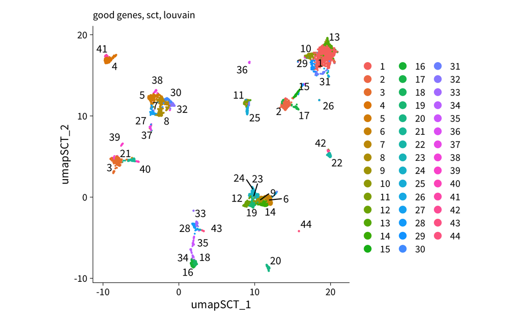

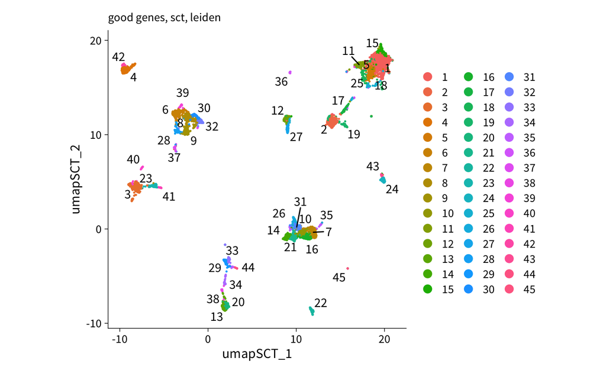

```r
for (genes in c("all", "good")) {
  for (norm.method in c("cpt", "sct")) {
    for (clust.method in c("louvain", "leiden")) {
      plot_umap(genes = genes, norm.method = norm.method, clust.method = clust.method)
    }
  }
}
```

# 7 Distribution of number of cells

```r
plot_n_cells_density <- function(genes, norm.method, clust.method) {
  dat <- get(glue("bf_{genes}"))@meta.data %>%
    group_by(!!sym(glue("{genes}_{norm.method}_{clust.method}_res10_merged"))) %>%
    tally() %>%
    ungroup() %>%
    rename(cluster = !!sym(glue("{genes}_{norm.method}_{clust.method}_res10_merged")),
           n_cells = n)

  ggplot(dat, aes(x = n_cells)) +
    geom_density(fill = "grey") +
    labs(subtitle = glue("{genes} genes, {norm.method}, {clust.method}")) +
    annotation_custom(grid::textGrob(
      x = unit(0.6, "npc"),
      y = unit(0.8, "npc"),
      label = c(glue("min = {min(dat$n_cells)}\\\n
           median = {median(dat$n_cells)}\\\n
           max = {max(dat$n_cells)}")),
      gp = grid::gpar(fontfamily = .use_font, cex = 0.75),
      hjust = 0
    )) +
    theme_half_open_grid()
}
```

```r
n_cell_density <- list()

for (genes in c("all", "good")) {
  for (norm.method in c("cpt", "sct")) {
    for (clust.method in c("louvain", "leiden")) {
      n_cell_density[[genes]][[norm.method]][[clust.method]] <- plot_n_cells_density(
        genes = genes,
        norm.method = norm.method,
        clust.method = clust.method
      )
    }
  }
}
```

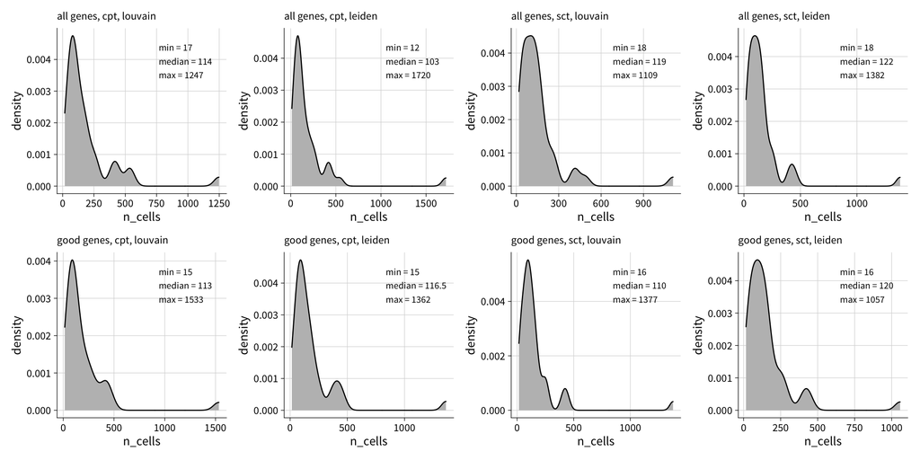

```r
unlist(n_cell_density, recursive = FALSE) %>%
  unlist(recursive = FALSE) %>%
  reduce(`+`) +
  plot_layout(ncol = 4)
```

```r
ggsave(here(basedir, "results/05a_clustering_test-parameters/plots/n-cells_density-plots.pdf"),
       device = cairo_pdf, width = 12, height = 6, units = "in")
```

# 8 Marker genes

## 8.1 Find Markers

```r
find_all_markers <- function(genes = c("all", "good"),
                             norm.method = c("cpt", "sct"),
                             clust.method = c("louvain", "leiden"),
                             suffix = "res10_merged") {
  object <- get(glue("bf_{genes}"))
  object <- SetIdent(object, value = glue("{genes}_{norm.method}_{clust.method}_{suffix}"))
  markers[[genes]][[norm.method]][[clust.method]] <-  FindAllMarkers(
    object,
    assay = "RNA",
    only.pos = TRUE,
    verbose = FALSE
  ) %>%
    filter(p_val_adj < 0.05) %>%
    as_tibble()
}
```

```r
markers <- list()

for (genes in c("all", "good")) {
  for (norm.method in c("cpt", "sct")) {
    for (clust.method in c("louvain", "leiden")) {

      markers[[genes]][[norm.method]][[clust.method]] <- find_all_markers(
        genes = genes,
        norm.method = norm.method,
        clust.method = clust.method
      )

    }
  }
}
```

## 8.2 Marker gene distributions

```r
plot_marker_density <- function(x) {
  dat <- x %>%
    group_by(cluster) %>%
    tally() %>%
    ungroup()

  ggplot(dat, aes(x = n)) +
    geom_density(fill = "grey") +
    labs(x = "n_markers",
         subtitle = glue("{genes} genes, {norm.method}, {clust.method}")) +
    annotation_custom(grid::textGrob(
      x = unit(0.6, "npc"),
      y = unit(0.8, "npc"),
      label = c(glue("min = {min(dat$n)}\\\n
           median = {median(dat$n)}\\\n
           max = {max(dat$n)}")),
      gp = grid::gpar(fontfamily = .use_font, cex = 0.75),
      hjust = 0
    )) +
    theme_half_open_grid()
}
```

```r
marker_density <- list()

for (genes in c("all", "good")) {
  for (norm.method in c("cpt", "sct")) {
    for (clust.method in c("louvain", "leiden")) {
      marker_density[[genes]][[norm.method]][[clust.method]] <- plot_marker_density(
        markers[[genes]][[norm.method]][[clust.method]]
      )
    }
  }
}
```

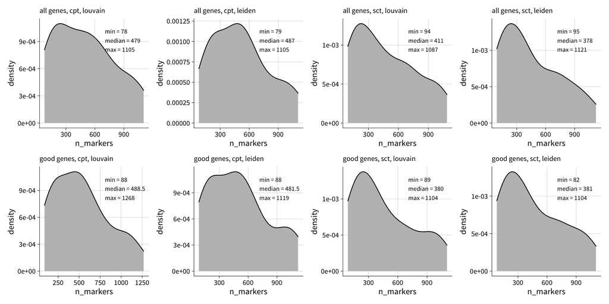

```r
unlist(marker_density, recursive = FALSE) %>%
  unlist(recursive = FALSE) %>%
  reduce(`+`) +
  plot_layout(ncol = 4)
```

```r
ggsave(here(basedir, "results/05a_clustering_test-parameters/plots/n-markers_density-plots.pdf"),
       device = cairo_pdf, width = 12, height = 6, units = "in")
```